# AASD4015 Project 1 Transfer learning Img Classifier, Comparing the accuarcy and speed of the model

##### By Team 55: Chuen Kei Ho 101410183 & Ka Tsun Chan 101420274

Introduction:

Transfer learning and Fine-tuning pre-trained model is very common in image classifications. For this project, we are fine-tuning a pre-trained VGG-16 model with the CIFAR 10 dataset which consists of 6000 images per class. We would like to examine the importance of unfreezing the layers in sequential orders versus unfreezing them altogether. We would compare the testing accuracy, speed of training as well as the average precision score of each of the output classes. For the first model, we will modify the fully connected layers for the classification of 10 classes in the dataset of interest, then unfreeze the top 2 CNN blocks in sequential orders for training. For the second model, we will modify the fully connected layers and unfreeze the top 2 CNN blocks altogether. The summary is as below:

```
Model 1a: Training from the Fully Connected Network onwardsTraining from the Fully Connected Network onwards (starting from VGG-16)
Model 1b: Un-freezing & training on the LAST CNN block onwards (starting from 1a)
Model 1c: Un-freezing & training on the LAST TWO CNN block onwards (starting from 1b)
Model 2 : unfreezing the last fully connected layers and the last 2 blocks together (starting from VGG-16)
```

CIFAR10 dataset link: https://www.cs.toronto.edu/~kriz/cifar.html

# Transfer learning - Fine-tuning

## Fine Tuning

```python
# Setting seeds to try and ensure we have the same results - this is not guaranteed across PyTorch releases.
import torch
import time
torch.manual_seed(42)
torch.backends.cudnn.deterministic = True
torch.backends.cudnn.benchmark = False

import matplotlib.pyplot as plt
```

```python
import torch.nn as nn
import torch.nn.functional as F
from torchvision import datasets, transforms, models
from torch.utils.data import DataLoader

from sklearn.model_selection import StratifiedShuffleSplit
from sklearn.metrics import precision_recall_curve, roc_curve, auc, average_precision_score
from sklearn.preprocessing import label_binarize
import numpy as np
```

```python
device = torch.device('cuda' if torch.cuda.is_available() else 'cpu')
device
```

```
device(type='cuda')
```

```python
###Preprocessing the data + Resize+ normalize + split the dataset
```

```python
# the average and standard deviation of pixel values in the CIFAR10 dataset
mean = [0.485, 0.456, 0.406]
std = [0.229, 0.224, 0.225]

transform = transforms.Compose([
    transforms.Resize((224, 224)),
    transforms.ToTensor(),
    transforms.Normalize(mean=mean, std=std)
    ])

train_set = datasets.CIFAR10(root='~/.pytorch/CIFAR10',train=True, download=True,transform=transform)
test_set = datasets.CIFAR10(root='~/.pytorch/CIFAR10',train=False, transform=transform)

# Get the labels for the dataset
labels = np.array(train_set.targets)
sss = StratifiedShuffleSplit(n_splits=1, test_size=0.2, random_state=42)
train_indices, val_indices = next(sss.split(np.zeros(len(labels)), labels))

train_dataset = torch.utils.data.Subset(train_set, train_indices)
val_dataset = torch.utils.data.Subset(train_set, val_indices)

train_loader = DataLoader(train_dataset, batch_size=64, shuffle=True)
val_loader = DataLoader(val_dataset, batch_size=64, shuffle=True)
test_loader = DataLoader(test_set, batch_size=64, shuffle=False)
```

```
Downloading https://www.cs.toronto.edu/~kriz/cifar-10-python.tar.gz to /root/.pytorch/CIFAR10/cifar-10-python.tar.gz
```

```
Extracting /root/.pytorch/CIFAR10/cifar-10-python.tar.gz to /root/.pytorch/CIFAR10
```

```python
#tried to see if the label is good enough
for images, labels in train_loader:
  print(images.size(), labels.size())
  break
```

```
torch.Size([64, 3, 224, 224]) torch.Size([64])
```

```python
### download and examine the VGG16 model
model1 = models.vgg16(pretrained=True)
model1
```

```
VGG(
  (features): Sequential(
    (0): Conv2d(3, 64, kernel_size=(3, 3), stride=(1, 1), padding=(1, 1))
    (1): ReLU(inplace=True)
    (2): Conv2d(64, 64, kernel_size=(3, 3), stride=(1, 1), padding=(1, 1))
    (3): ReLU(inplace=True)
    (4): MaxPool2d(kernel_size=2, stride=2, padding=0, dilation=1, ceil_mode=False)
    (5): Conv2d(64, 128, kernel_size=(3, 3), stride=(1, 1), padding=(1, 1))
    (6): ReLU(inplace=True)
    (7): Conv2d(128, 128, kernel_size=(3, 3), stride=(1, 1), padding=(1, 1))
    (8): ReLU(inplace=True)
    (9): MaxPool2d(kernel_size=2, stride=2, padding=0, dilation=1, ceil_mode=False)
    (10): Conv2d(128, 256, kernel_size=(3, 3), stride=(1, 1), padding=(1, 1))
    (11): ReLU(inplace=True)
    (12): Conv2d(256, 256, kernel_size=(3, 3), stride=(1, 1), padding=(1, 1))
    (13): ReLU(inplace=True)
    (14): Conv2d(256, 256, kernel_size=(3, 3), stride=(1, 1), padding=(1, 1))
    (15): ReLU(inplace=True)
    (16): MaxPool2d(kernel_size=2, stride=2, padding=0, dilation=1, ceil_mode=False)
    (17): Conv2d(256, 512, kernel_size=(3, 3), stride=(1, 1), padding=(1, 1))
    (18): ReLU(inplace=True)
    (19): Conv2d(512, 512, kernel_size=(3, 3), stride=(1, 1), padding=(1, 1))
    (20): ReLU(inplace=True)
    (21): Conv2d(512, 512, kernel_size=(3, 3), stride=(1, 1), padding=(1, 1))
    (22): ReLU(inplace=True)
    (23): MaxPool2d(kernel_size=2, stride=2, padding=0, dilation=1, ceil_mode=False)
    (24): Conv2d(512, 512, kernel_size=(3, 3), stride=(1, 1), padding=(1, 1))
    (25): ReLU(inplace=True)
    (26): Conv2d(512, 512, kernel_size=(3, 3), stride=(1, 1), padding=(1, 1))
    (27): ReLU(inplace=True)
    (28): Conv2d(512, 512, kernel_size=(3, 3), stride=(1, 1), padding=(1, 1))
    (29): ReLU(inplace=True)
    (30): MaxPool2d(kernel_size=2, stride=2, padding=0, dilation=1, ceil_mode=False)
  )
  (avgpool): AdaptiveAvgPool2d(output_size=(7, 7))
  (classifier): Sequential(
    (0): Linear(in_features=25088, out_features=4096, bias=True)
    (1): ReLU(inplace=True)
    (2): Dropout(p=0.5, inplace=False)
    (3): Linear(in_features=4096, out_features=4096, bias=True)
    (4): ReLU(inplace=True)
    (5): Dropout(p=0.5, inplace=False)
    (6): Linear(in_features=4096, out_features=1000, bias=True)
  )
)
```

```python
####freeze all the layers in the neural network and unfreeze them later
for param in model1.parameters():
  param.requires_grad = False
```

```python
#examine the classifier layers
model1.classifier
```

```
Sequential(
  (0): Linear(in_features=25088, out_features=4096, bias=True)
  (1): ReLU(inplace=True)
  (2): Dropout(p=0.5, inplace=False)
  (3): Linear(in_features=4096, out_features=4096, bias=True)
  (4): ReLU(inplace=True)
  (5): Dropout(p=0.5, inplace=False)
  (6): Linear(in_features=4096, out_features=1000, bias=True)
)
```

#### Remove the classifier, and start training from the last layer, replace the fully connected layer , 10 means 10 different classes in the CIFAR 10 dataset

```python
for i in range(0,7):
  model1.classifier[i].requires_grad = True
```

```python
## 10 classes
## using logit instead of softmax for output for numerical stability on small probabilities
model1.classifier[6] = nn.Sequential(
                      nn.Linear(4096, 512),
                      nn.ReLU(),
                      nn.Dropout(0.5),
                      nn.Linear(512, 10),
                      nn.LogSoftmax(dim=1)
                      )
```

```python
#examine the revised model architecture
model1.classifier
```

```
Sequential(
  (0): Linear(in_features=25088, out_features=4096, bias=True)
  (1): ReLU(inplace=True)
  (2): Dropout(p=0.5, inplace=False)
  (3): Linear(in_features=4096, out_features=4096, bias=True)
  (4): ReLU(inplace=True)
  (5): Dropout(p=0.5, inplace=False)
  (6): Sequential(
    (0): Linear(in_features=4096, out_features=512, bias=True)
    (1): ReLU()
    (2): Dropout(p=0.5, inplace=False)
    (3): Linear(in_features=512, out_features=10, bias=True)
    (4): LogSoftmax(dim=1)
  )
)
```

```python
#examine the revised model architecture
model1.features
```

```
Sequential(
  (0): Conv2d(3, 64, kernel_size=(3, 3), stride=(1, 1), padding=(1, 1))
  (1): ReLU(inplace=True)
  (2): Conv2d(64, 64, kernel_size=(3, 3), stride=(1, 1), padding=(1, 1))
  (3): ReLU(inplace=True)
  (4): MaxPool2d(kernel_size=2, stride=2, padding=0, dilation=1, ceil_mode=False)
  (5): Conv2d(64, 128, kernel_size=(3, 3), stride=(1, 1), padding=(1, 1))
  (6): ReLU(inplace=True)
  (7): Conv2d(128, 128, kernel_size=(3, 3), stride=(1, 1), padding=(1, 1))
  (8): ReLU(inplace=True)
  (9): MaxPool2d(kernel_size=2, stride=2, padding=0, dilation=1, ceil_mode=False)
  (10): Conv2d(128, 256, kernel_size=(3, 3), stride=(1, 1), padding=(1, 1))
  (11): ReLU(inplace=True)
  (12): Conv2d(256, 256, kernel_size=(3, 3), stride=(1, 1), padding=(1, 1))
  (13): ReLU(inplace=True)
  (14): Conv2d(256, 256, kernel_size=(3, 3), stride=(1, 1), padding=(1, 1))
  (15): ReLU(inplace=True)
  (16): MaxPool2d(kernel_size=2, stride=2, padding=0, dilation=1, ceil_mode=False)
  (17): Conv2d(256, 512, kernel_size=(3, 3), stride=(1, 1), padding=(1, 1))
  (18): ReLU(inplace=True)
  (19): Conv2d(512, 512, kernel_size=(3, 3), stride=(1, 1), padding=(1, 1))
  (20): ReLU(inplace=True)
  (21): Conv2d(512, 512, kernel_size=(3, 3), stride=(1, 1), padding=(1, 1))
  (22): ReLU(inplace=True)
  (23): MaxPool2d(kernel_size=2, stride=2, padding=0, dilation=1, ceil_mode=False)
  (24): Conv2d(512, 512, kernel_size=(3, 3), stride=(1, 1), padding=(1, 1))
  (25): ReLU(inplace=True)
  (26): Conv2d(512, 512, kernel_size=(3, 3), stride=(1, 1), padding=(1, 1))
  (27): ReLU(inplace=True)
  (28): Conv2d(512, 512, kernel_size=(3, 3), stride=(1, 1), padding=(1, 1))
  (29): ReLU(inplace=True)
  (30): MaxPool2d(kernel_size=2, stride=2, padding=0, dilation=1, ceil_mode=False)
)
```

### And we'll use NLLLoss as our criteria and we'll use the Adam optimizer.

```python
#use negative loglikelihood as criteria
criterion = nn.NLLLoss()
```

```python
# Use Adam optimizer
from torch.optim import Adam

model = model1.to(device)
optimizer = Adam(model1.parameters())
```

```python
#Specify epoch_number
N_epoch = 5
```

## Training from the Fully Connected Network onwards (Model 1a)

Re-training the model

#### to train the model and get the accuracy for freezing everything except the fully connected layers of the VGG16 model.

```python
model1 = model1.to(device)
optimizer = Adam(filter(lambda p: p.requires_grad, model1.parameters()))

num_epochs = N_epoch
batch_loss = 0
cum_epoch_loss = 0

train_loss_history_1a = []
val_loss_history_1a = []

start_time = time.time()

for e in range(num_epochs):

  cum_epoch_loss = 0
  epoch_train_loss = 0.0
  epoch_val_loss = 0.0

  for batch, (images, labels) in enumerate(train_loader,1):
    images = images.to(device)
    labels = labels.to(device)

    optimizer.zero_grad()
    logps = model1(images)
    loss = criterion(logps, labels)
    loss.backward()
    optimizer.step()

    batch_loss += loss.item()
    epoch_train_loss += loss.item()

    if batch % 100 == 0:
      print(f'Epoch({e+1}/{num_epochs}) : Batch number({batch}/{len(train_loader)}) : Batch loss : {loss.item()}')

  epoch_train_loss /= len(train_loader)
  train_loss_history_1a.append(epoch_train_loss)


  # Evaluate the model on the validation set
  model1.eval()
  with torch.no_grad():
    for images, labels in val_loader:
      images = images.to(device)
      labels = labels.to(device)

      logps = model1(images)
      loss = criterion(logps, labels)
      epoch_val_loss += loss.item()

    epoch_val_loss /= len(val_loader)
    val_loss_history_1a.append(epoch_val_loss)

  print(f'Epoch({e+1}/{num_epochs}) : Training loss : {epoch_train_loss} : Validation loss : {epoch_val_loss}')


end_time = time.time()
time_elapsed_1a = end_time - start_time
print(time_elapsed_1a)
```

```
Epoch(1/5) : Batch number(100/625) : Batch loss : 0.6044604182243347
Epoch(1/5) : Batch number(200/625) : Batch loss : 0.5842841863632202
Epoch(1/5) : Batch number(300/625) : Batch loss : 0.7054930329322815
Epoch(1/5) : Batch number(400/625) : Batch loss : 0.5354548692703247
Epoch(1/5) : Batch number(500/625) : Batch loss : 0.7734789252281189
Epoch(1/5) : Batch number(600/625) : Batch loss : 0.7259682416915894
Epoch(1/5) : Training loss : 0.715668133687973 : Validation loss : 0.509548624609686
Epoch(2/5) : Batch number(100/625) : Batch loss : 0.5810415148735046
Epoch(2/5) : Batch number(200/625) : Batch loss : 0.4802078306674957
Epoch(2/5) : Batch number(300/625) : Batch loss : 0.2799350619316101
Epoch(2/5) : Batch number(400/625) : Batch loss : 0.3608306348323822
Epoch(2/5) : Batch number(500/625) : Batch loss : 0.40757155418395996
Epoch(2/5) : Batch number(600/625) : Batch loss : 0.279032438993454
Epoch(2/5) : Training loss : 0.44203683540821076 : Validation loss : 0.44041636975327875
Epoch(3/5) : Batch number(100/625) : Batch loss : 0.40625
Epoch(3/5) : Batch number(200/625) : Batch loss : 0.3512813150882721
Epoch(3/5) : Batch number(300/625) : Batch loss : 0.4109914302825928
Epoch(3/5) : Batch number(400/625) : Batch loss : 0.34931108355522156
Epoch(3/5) : Batch number(500/625) : Batch loss : 0.39709869027137756
Epoch(3/5) : Batch number(600/625) : Batch loss : 0.1447046995162964
Epoch(3/5) : Training loss : 0.36858277220726016 : Validation loss : 0.4184760496874524
Epoch(4/5) : Batch number(100/625) : Batch loss : 0.28674572706222534
Epoch(4/5) : Batch number(200/625) : Batch loss : 0.3121085464954376
Epoch(4/5) : Batch number(300/625) : Batch loss : 0.33659642934799194
Epoch(4/5) : Batch number(400/625) : Batch loss : 0.255016565322876
Epoch(4/5) : Batch number(500/625) : Batch loss : 0.26425492763519287
Epoch(4/5) : Batch number(600/625) : Batch loss : 0.4136236011981964
Epoch(4/5) : Training loss : 0.2994307624816894 : Validation loss : 0.4378260713853654
Epoch(5/5) : Batch number(100/625) : Batch loss : 0.25868767499923706
Epoch(5/5) : Batch number(200/625) : Batch loss : 0.2646537125110626
Epoch(5/5) : Batch number(300/625) : Batch loss : 0.2452765852212906
Epoch(5/5) : Batch number(400/625) : Batch loss : 0.17834433913230896
Epoch(5/5) : Batch number(500/625) : Batch loss : 0.24160845577716827
Epoch(5/5) : Batch number(600/625) : Batch loss : 0.19169586896896362
Epoch(5/5) : Training loss : 0.24039642350673676 : Validation loss : 0.5004950090768231
479.64128255844116
```

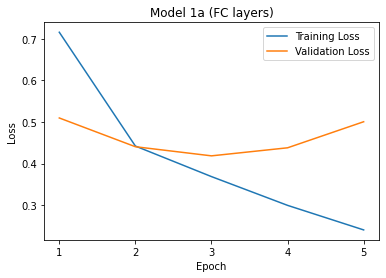

```
[0.715668133687973, 0.44203683540821076, 0.36858277220726016, 0.2994307624816894, 0.24039642350673676] [0.509548624609686, 0.44041636975327875, 0.4184760496874524, 0.4378260713853654, 0.5004950090768231]
```

```python
epoch_list = range(1, N_epoch+1)
plt.plot(epoch_list, train_loss_history_1a, label='Training Loss')
plt.plot(epoch_list, val_loss_history_1a, label='Validation Loss')
plt.xlabel('Epoch')
plt.ylabel('Loss')
plt.title('Model 1a (FC layers)')
plt.legend()
plt.xticks(list(epoch_list))
plt.show()

print(train_loss_history_1a, val_loss_history_1a)
```

### The accuracy of the model 1a

```
Test accuracy of model 1a: 82.89%
```

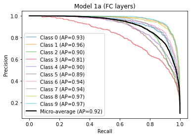

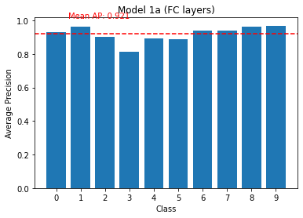

```python
# model1.to('cpu')

model1.eval()
with torch.no_grad():
    num_correct = 0
    total = 0
    y_true = []
    y_score = []

    #set_trace()
    for batch, (images, labels) in enumerate(test_loader,1):
        images = images.to(device)
        labels = labels.to(device)

        logps = model1(images)
        output = torch.exp(logps)

        # collect true labels and predicted scores for each image
        y_true.extend(labels.cpu().numpy())
        y_score.extend(output.cpu().numpy())

        # collect true labels and predicted scores for each image
        y_true.extend(labels.cpu().numpy())
        y_score.extend(output.cpu().numpy())

        # count number of correct predictions
        _, predicted = torch.max(logps.data, 1)
        total += labels.size(0)
        num_correct += (predicted == labels).sum().item()

    test_acc_1a = num_correct / total
    print(f'Test accuracy of model 1a: {test_acc_1a:.2%}')

    # binarize the true labels
    y_true_bin = label_binarize(y_true, classes=[0, 1, 2, 3, 4, 5, 6, 7, 8, 9])
    y_true_bin = np.array(y_true_bin)
    y_score = np.array(y_score)

    # compute precision-recall curve for each class
    precision = dict()
    recall = dict()
    average_precision = dict()

    for i in range(10):
        precision[i], recall[i], _ = precision_recall_curve(y_true_bin[:, i], y_score[:, i])
        average_precision[i] = average_precision_score(y_true_bin[:, i], y_score[:, i])

    # Compute the micro-average precision-recall curve
    precision["micro"], recall["micro"], _ = precision_recall_curve(y_true_bin.ravel(), y_score.ravel())
    average_precision["micro"] = average_precision_score(y_true_bin, y_score, average="micro")

    # Plot the individual class precision-recall curves with lighter colors and more transparency
    for i in range(10):
      plt.plot(recall[i], precision[i], label=f'Class {i} (AP={average_precision[i]:.2f})', alpha=0.5)

    # Plot the micro-average precision-recall curve with a darker color and no transparency
    plt.plot(recall["micro"], precision["micro"], label=f'Micro-average (AP={average_precision["micro"]:.2f})', color='k', linewidth=2)

    plt.xlabel('Recall')
    plt.ylabel('Precision')
    plt.title('Model 1a (FC layers)')
    plt.legend()
    plt.show()

    # compute average precision score for each class
    ap = dict()
    for i in range(10):
        ap[i] = average_precision_score(y_true_bin[:, i], y_score[:, i])
    # compute mean average precision score
    mean_ap = np.mean(list(ap.values()))

    # plot average precision score for each class
    fig, ax = plt.subplots()
    ax.bar(range(10), list(ap.values()))
    ax.axhline(mean_ap, color='r', linestyle='--')
    ax.text(0.5, 1.1*mean_ap, f'Mean AP: {mean_ap:.3f}', color='r')
    ax.set_xticks(range(10))
    ax.set_xticklabels(range(10))
    ax.set_xlabel('Class')
    ax.set_ylabel('Average Precision')
    plt.title('Model 1a (FC layers)')
    plt.show()
```

## Un-freezing & training on the LAST CNN block onwards (Model 1b)

### Re-training the model 1b

### index 24,31

```python
#last CNN Block in the feature extraction layers
for i in range(24,31):
  model1.features[i].requires_grad = True
```

```python
model1 = model1.to(device)
optimizer = Adam(filter(lambda p: p.requires_grad, model1.parameters()))

train_loss_history_1b = []
val_loss_history_1b = []

num_epochs = N_epoch
batch_loss = 0
cum_epoch_loss = 0


start_time = time.time()


for e in range(num_epochs):
  cum_epoch_loss = 0
  epoch_train_loss = 0.0
  epoch_val_loss = 0.0

  for batch, (images, labels) in enumerate(train_loader,1):
    images = images.to(device)
    labels = labels.to(device)

    optimizer.zero_grad()
    logps = model1(images)
    loss = criterion(logps, labels)
    loss.backward()
    optimizer.step()

    batch_loss += loss.item()
    epoch_train_loss += loss.item()

    if batch % 100 == 0:
      print(f'Epoch({e+1}/{num_epochs}) : Batch number({batch}/{len(train_loader)}) : Batch loss : {loss.item()}')

  epoch_train_loss /= len(train_loader)
  train_loss_history_1b.append(epoch_train_loss)

  print(f'Training loss : {epoch_train_loss}')

  model1.eval()
  with torch.no_grad():
    for images, labels in val_loader:
      images = images.to(device)
      labels = labels.to(device)

      logps = model1(images)
      loss = criterion(logps, labels)
      epoch_val_loss += loss.item()

    epoch_val_loss /= len(val_loader)
    val_loss_history_1b.append(epoch_val_loss)
  print(f'Epoch({e+1}/{num_epochs}) : Training loss : {epoch_train_loss} : Validation loss : {epoch_val_loss}')

end_time = time.time()
time_elapsed_1b = end_time - start_time
print(f'Time elapsed: {time_elapsed_1b}')
```

```
Epoch(1/5) : Batch number(100/625) : Batch loss : 0.2865169644355774
Epoch(1/5) : Batch number(200/625) : Batch loss : 0.2222081571817398
Epoch(1/5) : Batch number(300/625) : Batch loss : 0.15718376636505127
Epoch(1/5) : Batch number(400/625) : Batch loss : 0.3809202015399933
Epoch(1/5) : Batch number(500/625) : Batch loss : 0.2075466811656952
Epoch(1/5) : Batch number(600/625) : Batch loss : 0.1643606722354889
Training loss : 0.2021612346172333
Epoch(1/5) : Training loss : 0.2021612346172333 : Validation loss : 0.5091889546175671
Epoch(2/5) : Batch number(100/625) : Batch loss : 0.1353125423192978
Epoch(2/5) : Batch number(200/625) : Batch loss : 0.17753399908542633
Epoch(2/5) : Batch number(300/625) : Batch loss : 0.13277865946292877
Epoch(2/5) : Batch number(400/625) : Batch loss : 0.16282279789447784
Epoch(2/5) : Batch number(500/625) : Batch loss : 0.335049033164978
Epoch(2/5) : Batch number(600/625) : Batch loss : 0.09447672218084335
Training loss : 0.13783690671026708
Epoch(2/5) : Training loss : 0.13783690671026708 : Validation loss : 0.5588457689733263
Epoch(3/5) : Batch number(100/625) : Batch loss : 0.059977978467941284
Epoch(3/5) : Batch number(200/625) : Batch loss : 0.06902039796113968
Epoch(3/5) : Batch number(300/625) : Batch loss : 0.058645956218242645
Epoch(3/5) : Batch number(400/625) : Batch loss : 0.12992149591445923
Epoch(3/5) : Batch number(500/625) : Batch loss : 0.09284494817256927
Epoch(3/5) : Batch number(600/625) : Batch loss : 0.17496107518672943
Training loss : 0.09635471425503492
Epoch(3/5) : Training loss : 0.09635471425503492 : Validation loss : 0.5946334686818396
Epoch(4/5) : Batch number(100/625) : Batch loss : 0.0489305816590786
Epoch(4/5) : Batch number(200/625) : Batch loss : 0.0599776953458786
Epoch(4/5) : Batch number(300/625) : Batch loss : 0.06054260581731796
Epoch(4/5) : Batch number(400/625) : Batch loss : 0.05890810862183571
Epoch(4/5) : Batch number(500/625) : Batch loss : 0.03310830146074295
Epoch(4/5) : Batch number(600/625) : Batch loss : 0.2022613286972046
Training loss : 0.07632007773146034
Epoch(4/5) : Training loss : 0.07632007773146034 : Validation loss : 0.6854778355118006
Epoch(5/5) : Batch number(100/625) : Batch loss : 0.10973653942346573
Epoch(5/5) : Batch number(200/625) : Batch loss : 0.05577299743890762
Epoch(5/5) : Batch number(300/625) : Batch loss : 0.07667619735002518
Epoch(5/5) : Batch number(400/625) : Batch loss : 0.06057960167527199
Epoch(5/5) : Batch number(500/625) : Batch loss : 0.059177689254283905
Epoch(5/5) : Batch number(600/625) : Batch loss : 0.056959304958581924
Training loss : 0.058524222777038816
Epoch(5/5) : Training loss : 0.058524222777038816 : Validation loss : 0.7185192286588584
Time elapsed: 473.55689883232117
```

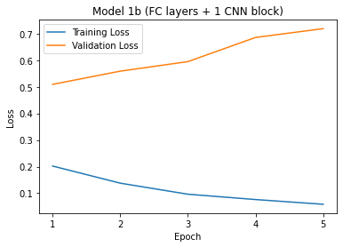

```
[0.2021612346172333, 0.13783690671026708, 0.09635471425503492, 0.07632007773146034, 0.058524222777038816] [0.5091889546175671, 0.5588457689733263, 0.5946334686818396, 0.6854778355118006, 0.7185192286588584]
```

```python
plt.plot(epoch_list, train_loss_history_1b, label='Training Loss')
plt.plot(epoch_list, val_loss_history_1b, label='Validation Loss')
plt.xlabel('Epoch')
plt.ylabel('Loss')
plt.title('Model 1b (FC layers + 1 CNN block)')
plt.legend()
plt.xticks(list(epoch_list))
plt.show()


print(train_loss_history_1b, val_loss_history_1b)
```

### The accuracy of the model 1b

```
Test accuracy of Model 1b: 84.00%
```

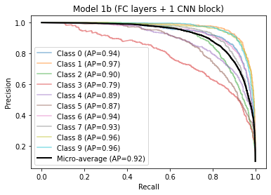

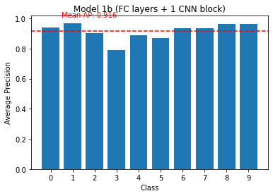

```python
model1.eval()
with torch.no_grad():
    num_correct = 0
    total = 0
    y_true = []
    y_score = []

    #set_trace()
    for batch, (images, labels) in enumerate(test_loader,1):
        images = images.to(device)
        labels = labels.to(device)

        logps = model1(images)
        output = torch.exp(logps)

        # collect true labels and predicted scores for each image
        y_true.extend(labels.cpu().numpy())
        y_score.extend(output.cpu().numpy())

        # collect true labels and predicted scores for each image
        y_true.extend(labels.cpu().numpy())
        y_score.extend(output.cpu().numpy())


        # count number of correct predictions
        _, predicted = torch.max(logps.data, 1)
        total += labels.size(0)
        num_correct += (predicted == labels).sum().item()

    test_acc_1b = num_correct / total
    print(f'Test accuracy of Model 1b: {test_acc_1b:.2%}')

    # binarize the true labels
    y_true_bin = label_binarize(y_true, classes=[0, 1, 2, 3, 4, 5, 6, 7, 8, 9])
    y_true_bin = np.array(y_true_bin)
    y_score = np.array(y_score)

    # compute precision-recall curve for each class
    precision = dict()
    recall = dict()
    average_precision = dict()

    for i in range(10):
        precision[i], recall[i], _ = precision_recall_curve(y_true_bin[:, i], y_score[:, i])
        average_precision[i] = average_precision_score(y_true_bin[:, i], y_score[:, i])

    # Compute the micro-average precision-recall curve
    precision["micro"], recall["micro"], _ = precision_recall_curve(y_true_bin.ravel(), y_score.ravel())
    average_precision["micro"] = average_precision_score(y_true_bin, y_score, average="micro")

    # Plot the individual class precision-recall curves with lighter colors and more transparency
    for i in range(10):
      plt.plot(recall[i], precision[i], label=f'Class {i} (AP={average_precision[i]:.2f})', alpha=0.5)

    # Plot the micro-average precision-recall curve with a darker color and no transparency
    plt.plot(recall["micro"], precision["micro"], label=f'Micro-average (AP={average_precision["micro"]:.2f})', color='k', linewidth=2)

    plt.xlabel('Recall')
    plt.ylabel('Precision')
    plt.title('Model 1b (FC layers + 1 CNN block)')
    plt.legend()
    plt.show()

    # compute average precision score for each class
    ap = dict()
    for i in range(10):
        ap[i] = average_precision_score(y_true_bin[:, i], y_score[:, i])
    # compute mean average precision score
    mean_ap = np.mean(list(ap.values()))

    # plot average precision score for each class
    fig, ax = plt.subplots()
    ax.bar(range(10), list(ap.values()))
    ax.axhline(mean_ap, color='r', linestyle='--')
    ax.text(0.5, 1.1*mean_ap, f'Mean AP: {mean_ap:.3f}', color='r')
    ax.set_xticks(range(10))
    ax.set_xticklabels(range(10))
    ax.set_xlabel('Class')
    ax.set_ylabel('Average Precision')
    plt.title('Model 1b (FC layers + 1 CNN block)')
    plt.show()
```

## Un-freezing & training on the LAST TWO CNN block onwards (Model 1c)

### Re-training the model

```python
for i in range(17, 24):
  model1.features[i].requires_grad = True
```

```python
model1 = model.to(device)
optimizer = Adam(filter(lambda p: p.requires_grad, model1.parameters()))

num_epochs = N_epoch
batch_loss = 0
cum_epoch_loss = 0
train_loss_history_1c = []
val_loss_history_1c = []


start_time = time.time()


for e in range(num_epochs):
  cum_epoch_loss = 0
  epoch_train_loss = 0.0
  epoch_val_loss = 0.0

  for batch, (images, labels) in enumerate(train_loader,1):
    images = images.to(device)
    labels = labels.to(device)

    optimizer.zero_grad()
    logps = model(images)
    loss = criterion(logps, labels)
    loss.backward()
    optimizer.step()

    batch_loss += loss.item()
    epoch_train_loss += loss.item()

    if batch % 100 == 0:
      print(f'Epoch({e+1}/{num_epochs} : Batch number({batch}/{len(train_loader)}) : Batch loss : {loss.item()}')

  epoch_train_loss /= len(train_loader)
  train_loss_history_1c.append(epoch_train_loss)

  print(f'Training loss : {epoch_train_loss}')

  model1.eval()
  with torch.no_grad():
    for images, labels in val_loader:
      images = images.to(device)
      labels = labels.to(device)

      logps = model1(images)
      loss = criterion(logps, labels)
      epoch_val_loss += loss.item()

    epoch_val_loss /= len(val_loader)
    val_loss_history_1c.append(epoch_val_loss)

  print(f'Epoch({e+1}/{num_epochs}) : Training loss : {epoch_train_loss} : Validation loss : {epoch_val_loss}')


end_time = time.time()
time_elapsed_1c = end_time - start_time
```

```
Epoch(1/5 : Batch number(100/625) : Batch loss : 0.03632257133722305
Epoch(1/5 : Batch number(200/625) : Batch loss : 0.057763438671827316
Epoch(1/5 : Batch number(300/625) : Batch loss : 0.03729322925209999
Epoch(1/5 : Batch number(400/625) : Batch loss : 0.17384624481201172
Epoch(1/5 : Batch number(500/625) : Batch loss : 0.07975870370864868
Epoch(1/5 : Batch number(600/625) : Batch loss : 0.05426764860749245
Training loss : 0.06256860256195068
Epoch(1/5) : Training loss : 0.06256860256195068 : Validation loss : 0.7573354752959719
Epoch(2/5 : Batch number(100/625) : Batch loss : 0.01052470039576292
Epoch(2/5 : Batch number(200/625) : Batch loss : 0.04142731428146362
Epoch(2/5 : Batch number(300/625) : Batch loss : 0.016295118257403374
Epoch(2/5 : Batch number(400/625) : Batch loss : 0.17685528099536896
Epoch(2/5 : Batch number(500/625) : Batch loss : 0.09176089614629745
Epoch(2/5 : Batch number(600/625) : Batch loss : 0.047209978103637695
Training loss : 0.04273784842975438
Epoch(2/5) : Training loss : 0.04273784842975438 : Validation loss : 0.7930167150820137
Epoch(3/5 : Batch number(100/625) : Batch loss : 0.034617021679878235
Epoch(3/5 : Batch number(200/625) : Batch loss : 0.13872314989566803
Epoch(3/5 : Batch number(300/625) : Batch loss : 0.03296207636594772
Epoch(3/5 : Batch number(400/625) : Batch loss : 0.031483862549066544
Epoch(3/5 : Batch number(500/625) : Batch loss : 0.058815788477659225
Epoch(3/5 : Batch number(600/625) : Batch loss : 0.031679585576057434
Training loss : 0.047512039044499396
Epoch(3/5) : Training loss : 0.047512039044499396 : Validation loss : 0.9042362917190904
Epoch(4/5 : Batch number(100/625) : Batch loss : 0.17071552574634552
Epoch(4/5 : Batch number(200/625) : Batch loss : 0.006033393554389477
Epoch(4/5 : Batch number(300/625) : Batch loss : 0.031233061105012894
Epoch(4/5 : Batch number(400/625) : Batch loss : 0.06873030960559845
Epoch(4/5 : Batch number(500/625) : Batch loss : 0.03396168351173401
Epoch(4/5 : Batch number(600/625) : Batch loss : 0.17032627761363983
Training loss : 0.037311039890442044
Epoch(4/5) : Training loss : 0.037311039890442044 : Validation loss : 0.9383028172383643
Epoch(5/5 : Batch number(100/625) : Batch loss : 0.02256958745419979
Epoch(5/5 : Batch number(200/625) : Batch loss : 0.01558605208992958
Epoch(5/5 : Batch number(300/625) : Batch loss : 0.0444047749042511
Epoch(5/5 : Batch number(400/625) : Batch loss : 0.03626534715294838
Epoch(5/5 : Batch number(500/625) : Batch loss : 0.1454477161169052
Epoch(5/5 : Batch number(600/625) : Batch loss : 0.003604322671890259
Training loss : 0.03971125192195177
Epoch(5/5) : Training loss : 0.03971125192195177 : Validation loss : 0.9522844301477359
```

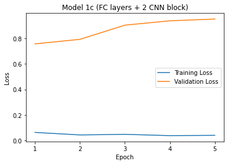

```
[0.06256860256195068, 0.04273784842975438, 0.047512039044499396, 0.037311039890442044, 0.03971125192195177] [0.7573354752959719, 0.7930167150820137, 0.9042362917190904, 0.9383028172383643, 0.9522844301477359]
```

```python
plt.plot(epoch_list, train_loss_history_1c, label='Training Loss')
plt.plot(epoch_list, val_loss_history_1c, label='Validation Loss')
plt.xlabel('Epoch')
plt.ylabel('Loss')
plt.title('Model 1c (FC layers + 2 CNN block)')
plt.legend()
plt.xticks(list(epoch_list))
plt.show()

print(train_loss_history_1c, val_loss_history_1c)
```

### The accuracy of the model of 1c

```
Test accuracy for model 1c: 83.68%
```

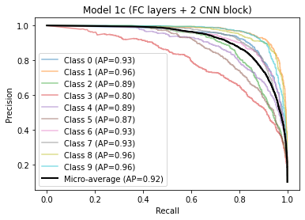

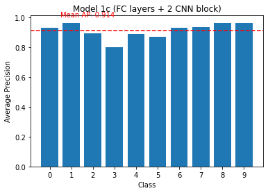

```python
model1.eval()
with torch.no_grad():
    num_correct = 0
    total = 0
    y_true = []
    y_score = []

    #set_trace()
    for batch, (images, labels) in enumerate(test_loader,1):
        images = images.to(device)
        labels = labels.to(device)

        logps = model1(images)
        output = torch.exp(logps)

        # collect true labels and predicted scores for each image
        y_true.extend(labels.cpu().numpy())
        y_score.extend(output.cpu().numpy())

        # collect true labels and predicted scores for each image
        y_true.extend(labels.cpu().numpy())
        y_score.extend(output.cpu().numpy())

        # count number of correct predictions
        _, predicted = torch.max(logps.data, 1)
        total += labels.size(0)
        num_correct += (predicted == labels).sum().item()

    test_acc_1c = num_correct / total
    print(f'Test accuracy for model 1c: {test_acc_1c:.2%}')

    # binarize the true labels
    y_true_bin = label_binarize(y_true, classes=[0, 1, 2, 3, 4, 5, 6, 7, 8, 9])
    y_true_bin = np.array(y_true_bin)
    y_score = np.array(y_score)

    # compute precision-recall curve for each class
    precision = dict()
    recall = dict()
    average_precision = dict()

    for i in range(10):
        precision[i], recall[i], _ = precision_recall_curve(y_true_bin[:, i], y_score[:, i])
        average_precision[i] = average_precision_score(y_true_bin[:, i], y_score[:, i])

    # Compute the micro-average precision-recall curve
    precision["micro"], recall["micro"], _ = precision_recall_curve(y_true_bin.ravel(), y_score.ravel())
    average_precision["micro"] = average_precision_score(y_true_bin, y_score, average="micro")

    # Plot the individual class precision-recall curves with lighter colors and more transparency
    for i in range(10):
      plt.plot(recall[i], precision[i], label=f'Class {i} (AP={average_precision[i]:.2f})', alpha=0.5)

    # Plot the micro-average precision-recall curve with a darker color and no transparency
    plt.plot(recall["micro"], precision["micro"], label=f'Micro-average (AP={average_precision["micro"]:.2f})', color='k', linewidth=2)

    plt.xlabel('Recall')
    plt.ylabel('Precision')
    plt.title('Model 1c (FC layers + 2 CNN block)')
    plt.legend()
    plt.show()

    # compute average precision score for each class
    ap = dict()
    for i in range(10):
        ap[i] = average_precision_score(y_true_bin[:, i], y_score[:, i])
    # compute mean average precision score
    mean_ap = np.mean(list(ap.values()))

    # plot average precision score for each class
    fig, ax = plt.subplots()
    ax.bar(range(10), list(ap.values()))
    ax.axhline(mean_ap, color='r', linestyle='--')
    ax.text(0.5, 1.1*mean_ap, f'Mean AP: {mean_ap:.3f}', color='r')
    ax.set_xticks(range(10))
    ax.set_xticklabels(range(10))
    ax.set_xlabel('Class')
    ax.set_ylabel('Average Precision')
    plt.title('Model 1c (FC layers + 2 CNN block)')
    plt.show()
```